# Effect of recall on distribution of distances.

Apply various recall values to organisms and check how it affects the distribution of distances.

Author

Thelma Panaïotis

Let’s use the agent-based model positions that are representative of plankton position and arbitrary remove some points to simulate lower recall, recompute distances and check if they are representative of overall distances.

First, we need to learn the relationship between points recall and distance recall, because these values are not equivalent. For example, in an image with 10 points, we initially have 45 (10×9/2) unique distances. If we remove one point, the point recall is now 90%, but we now have 36 (9×8/2) distances, corresponding to a distance recall of 80% (36/45). By knowing the distance recall for each point recall, we can directly subsample computed distances.

```r
#|cache: false
source("utils.R")
```

## Load data

```r
# Subsample of images
load("data/00.images_sub.Rdata")

# Load all distances, plankton and random
plankton_dist <- read_parquet("data/distances/02a.all_distances_plankton.parquet")
rand_dist <- read_parquet("data/distances/02a.all_distances_random.parquet")

# Keep only distances below distance threshold
plankton_dist <- plankton_dist %>% filter(dist < dist_thr)
rand_dist <- rand_dist %>% filter(dist < dist_thr)

# Generate a subsample of distances from the subsample of images
plankton_dist_sub <- plankton_dist %>% filter(img_name %in% images_sub$img_name)

# Null dataset
load("data/04b.null_ks.Rdata")
```

## Learn distance recall from points recall

The recall values from classification are for points. We can retrieve the recall of distances from points but this is costly in terms of computation. Instead, we can learn this relationship on a subset of distances and then apply it to the whole dataset.

Because we are going to apply the recall values to the points and not the distances, we first need to generate a list of points.

```r
points <- plankton_dist_sub %>%
  select(img_name, p1, p2) %>%
  pivot_longer(p1:p2, values_to = "point", names_to = NULL) %>%
  distinct() %>%
  arrange(img_name, point)
```

For each recall value, we:

- drop points (randomly)
- get distances between remaining points

```r
# Recall values to try
recall_values <- seq(0.1, 1, by = 0.1)


# Loop over recall values
rec_dist_pt <- lapply(recall_values, function(rec_val) {
  print(rec_val)

  # Subsample points (i.e. apply recall)
  points_sub <- points %>%
    slice_sample(prop = rec_val) %>%
    arrange(img_name, point)

  # Get all combinations of remaining points
  cross_sub <- points_sub %>%
    rename(p1 = point) %>%
    mutate(p2 = p1) %>%
    group_by(img_name) %>%
    expand(p1, p2) %>%
    ungroup() %>%
    filter(p1 != p2)

  # Let’s find distances between these points
  dist_sub <- cross_sub %>%
    left_join(plankton_dist_sub, by = join_by(img_name, p1, p2)) %>%
    drop_na(dist) %>%
    mutate(rec_val = rec_val)

  # Return
  return(dist_sub)
}) %>%
  bind_rows()
```

```
[1] 0.1
[1] 0.2
[1] 0.3
[1] 0.4
[1] 0.5
[1] 0.6
[1] 0.7
[1] 0.8
[1] 0.9
[1] 1
```

Let’s check how the distance recall varies with points recall.

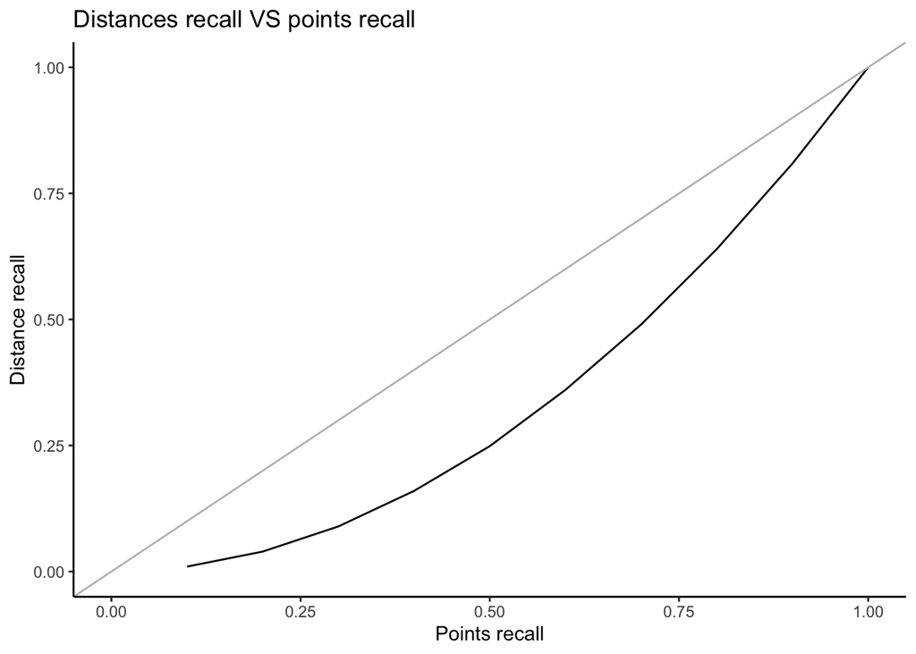

```r
# Compute number and proportion of retained distances
rec_summ <- rec_dist_pt %>%
  count(rec_val, name = "n_dist") %>%
  mutate(prop_dist = n_dist / max(n_dist))

ggplot(rec_summ) +
  geom_path(aes(x = rec_val, y = prop_dist)) +
  geom_abline(slope = 1, intercept = 0, colour = "grey") +
  xlim(0, 1) + ylim(0, 1) +
  labs(x = "Points recall", y = "Distance recall") +
  ggtitle("Distances recall VS points recall") +
  theme_classic()
```

This means that if point recall is 0.5, distance recall is ~0.25.

Let’s apply these distance recall values to our dataset of observations.

## Apply to observations

Similarly as before, for each recall value, we:

- subsample distances, both plankton and null distances
- compute Kuiper statistic between plankton and null distances

```r
# Loop over recall values
rec_dist <- lapply(1:nrow(rec_summ), function(i) {
  print(i)
  # Get row
  r <- rec_summ %>% slice(i)

  # Subsample plankton distances
  s_plankton_dist <- plankton_dist %>% slice_sample(prop = r$prop_dist)

  # Subsample random distances
  s_rand_dist <- rand_dist %>% slice_sample(prop = r$prop_dist)

  # Compute quantiles
  plank_dist_qt <- quantile(s_plankton_dist$dist, probs = probs, names = FALSE)
  rand_dist_qt <- quantile(s_rand_dist$dist, probs = probs, names = FALSE)

  # Compute Kuiper statistic
  ks <- kuiper_stat(plank_dist_qt, rand_dist_qt)

  # Format results
  res <- tibble(
    rec_val = r$rec_val,
    n_dist_plank = nrow(s_plankton_dist),
    n_dist_rand = nrow(s_rand_dist),
    n_dist = (n_dist_plank + n_dist_rand) / 2,
    kuiper_stat = ks,
    plank_qt = list(plank_dist_qt),
    rand_qt = list(rand_dist_qt)
  )

  # Return
  return(res)
}) %>%
  bind_rows()
```

```
[1] 1
[1] 2
[1] 3
[1] 4
[1] 5
[1] 6
[1] 7
[1] 8
[1] 9
[1] 10
```

```r
# Log transform kuiper stat and number of distances
rec_dist <- rec_dist %>%
  mutate(
    log_n_dist = log10(n_dist),
    log_kuiper_stat = log10(kuiper_stat)
  )
```

And finally plot Kuiper stat VS number of distances.

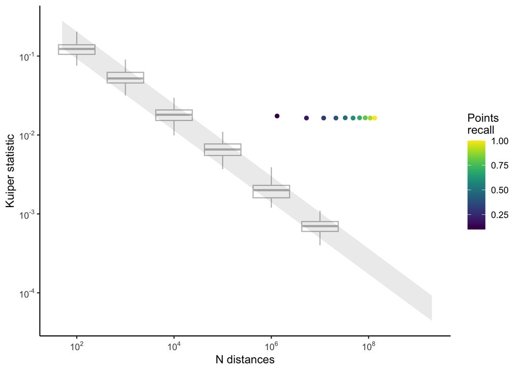

```r
# Plot Kuiper stat VS number of distances
ggplot() +
  geom_boxplot(data = null_ks_n_dist, aes(x = log_n_dist, y = log_kuiper_stat, group = log_n_dist), colour = "gray", outlier.shape = NA) +
  geom_polygon(data = null_ks_rib, aes(x = log_n_dist, y = y), alpha = 0.1) +
  geom_point(data = rec_dist, aes(x = log_n_dist, y = log_kuiper_stat, colour = rec_val)) +
  labs(x = "N distances", y = "Kuiper statistic", colour = "Points\nrecall") +
  scale_colour_viridis_c() +
  scale_x_continuous(labels = label_math(expr = 10^.x, format = force), breaks = seq(2, 8, by = 2)) +
  scale_y_continuous(labels = label_math(expr = 10^.x, format = force)) +
  theme_classic()
```

**Note**

The KS value is barely affected by recall. Given the number of observations, it’s fine!

Save for future plots.

```r
save(rec_dist, file = "data/13.rec_dist.Rdata")
```

## Look at recall values in the dataset

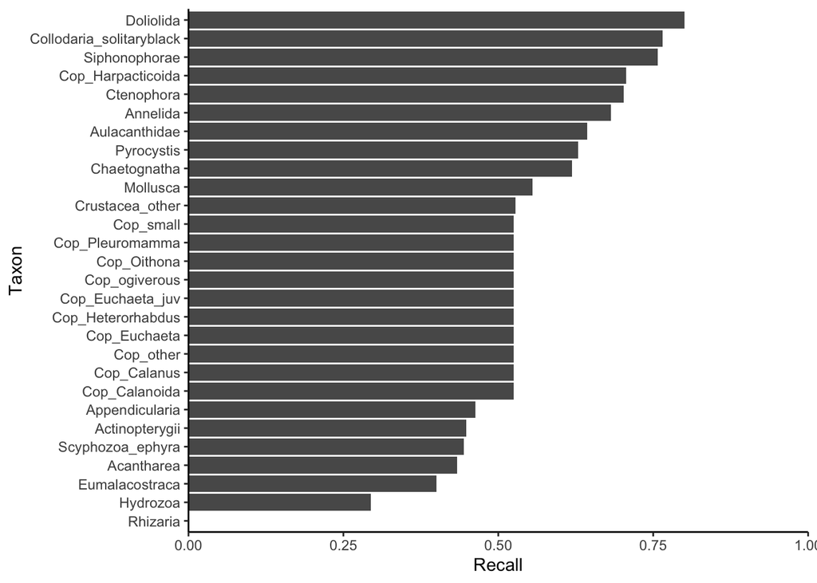

```r
# Read table of clean taxa with match-up for report taxonomy
clean_taxa <- read_csv("data/raw/taxa_list.csv", show_col_types = FALSE) %>% select(taxon = orig_name, new_taxon = new_name, report_taxon = report_name)

# Read classification report
rep_obs <- read_csv("data/raw/classif_report_aft_thres.csv", show_col_types = FALSE) %>%
  select(report_taxon = class, recall, precision)

# Join clean taxon and classification report
rep_obs <- clean_taxa %>%
  left_join(rep_obs, by = join_by(report_taxon)) %>%
  drop_na(new_taxon) %>% # drop unwanted taxa
  select(taxon = new_taxon, recall, precision) %>% # keep only relevent columns
  distinct() %>% # drop duplicates
  filter(!str_detect(taxon, "colonial")) # drop colonial Collodaria

# Plot recall per taxon
rep_obs %>%
  arrange(recall) %>%
  mutate(taxon = fct_inorder(taxon)) %>%
  ggplot() +
  geom_col(aes(y = taxon, x = recall)) +
  scale_x_continuous(expand = c(0,0), limits = c(0, 1)) +
  labs(x = "Recall", y = "Taxon") +
  theme_classic()
```